# Can recidivism be predicted?

Kamya Khandelwal, Revathi V. Machan, Claudia Schreier

May 14, 2024

# Recidivism in the State of Georgia

As a side quest from his mission of removing reproductive rights as the Governor of Georgia, Brian Kemp has asked the team at Marie Antoinette Predictions (MAP) to create a model to predict recidivism, or the probability that someone convicted of a crime will be convicted of another crime in the future. Georgia is one of the leading states with the highest per capita amount of people under correctional supervision. Nationally, around 65 percent of formerly incarcerated people will reoffend, and 30 percent of people will find themselves back in prison within three years, making this issue one of high importance for criminal justice reforms. Recidivism costs the state a lot of money, from continued legal fees and resources for incarcerated individuals. Research about recidivism has been embedded into the management framework of the National Institute of Justice (NIJ), an organization that sponsors government-funded criminal justice research. the NIJ believes that studying recidivism is “one of the most fundamental concepts in criminal justice” because it is something that prison re-entry programs actively are designed to avoid.

## Introducing our work

Recidivism is a concept to study in a data-driven approach. MAP obtained a dataset from the NIG with re-entry data, including the original crime, some demographic information, and other types of personal information about the incarcerated individual, along with whether or not the person was convicted of another crime. Using linear models, we can predict whether or not a person will be convicted of a second crime after leaving prison.

# Exploring our model’s components

This code chunk performs several operations on our recidivism dataset `rDivism`. We selected the following variables `gender`, `gang_affiliated`, `age_at_release`, `education_level`, `prison_offense`, `prison_years`, `recidivism_within_3years`, and then gather these selected columns into key-value pairs to reshape the data. We do this so that the grouped bar plot visualizes the associations between different features and the likelihood of recidivism within 3 years, providing insights into potential predictive factors for recidivism.

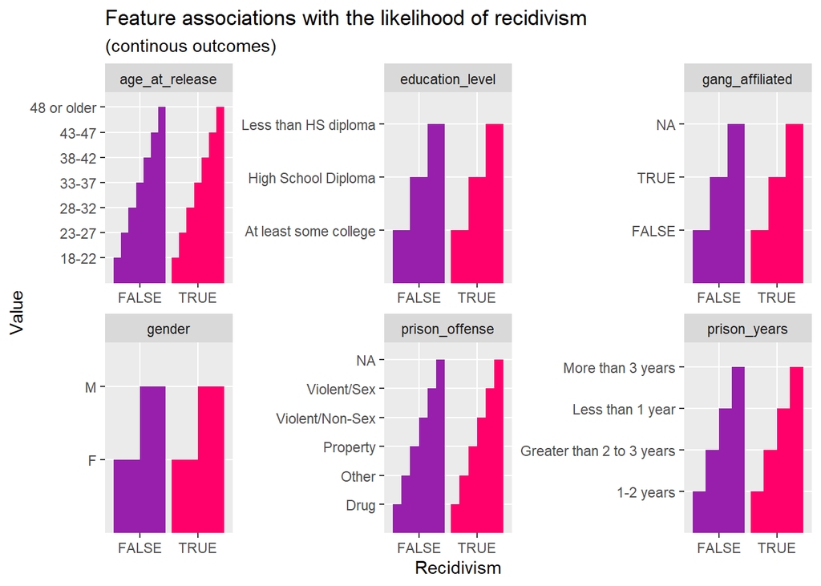

```r
rDivism %>%
  dplyr::select(gender,gang_affiliated, age_at_release, education_level, prison_offense, prison_years, recidivism_within_3years) %>%
  gather(Variable, value, -recidivism_within_3years) %>%
    ggplot(aes(recidivism_within_3years, value, fill=recidivism_within_3years)) +
      geom_bar(position = "dodge", stat = "summary", fun = "mean") +
      facet_wrap(~Variable, scales = "free") +
      scale_fill_manual(values = palette2) +
      labs(x="Recidivism", y="Value",
           title = "Feature associations with the likelihood of recidivism",
           subtitle = "(continous outcomes)") +
      theme(legend.position = "none")
```

This code chunk visualizes the distribution of different features, comparing those who experienced recidivism within three years against those who did not, offering insights into the potential differences in feature distributions between the two groups.

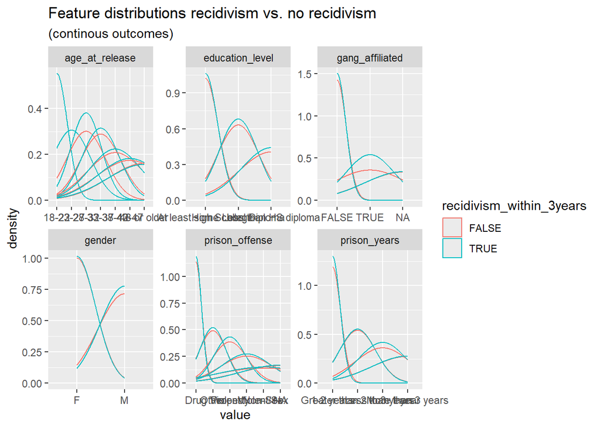

```r
rDivism %>%
    dplyr::select(gender,gang_affiliated, age_at_release, education_level, prison_offense, prison_years, recidivism_within_3years) %>%
    gather(Variable, value, -recidivism_within_3years) %>%
    ggplot() +
    geom_density(aes(value, color=recidivism_within_3years), fill = "transparent") +
    facet_wrap(~Variable, scales = "free") +
    scale_fill_manual(values = palette2) +
    labs(title = "Feature distributions recidivism vs. no recidivism",
         subtitle = "(continous outcomes)")
```

The code displays grouped bar plots that illustrate the association between various features (variables like gender, prison offense, prison years) and the likelihood of recidivism. Each bar represents the count of occurrences for different values of the features, separated by the outcome of recidivism (whether it occurred or not). The facet grid arrangement allows for easy comparison across different variables, while the color differentiation helps distinguish between the two recidivism outcomes. This visualization provides insights into how different factors may influence the likelihood of recidivism.

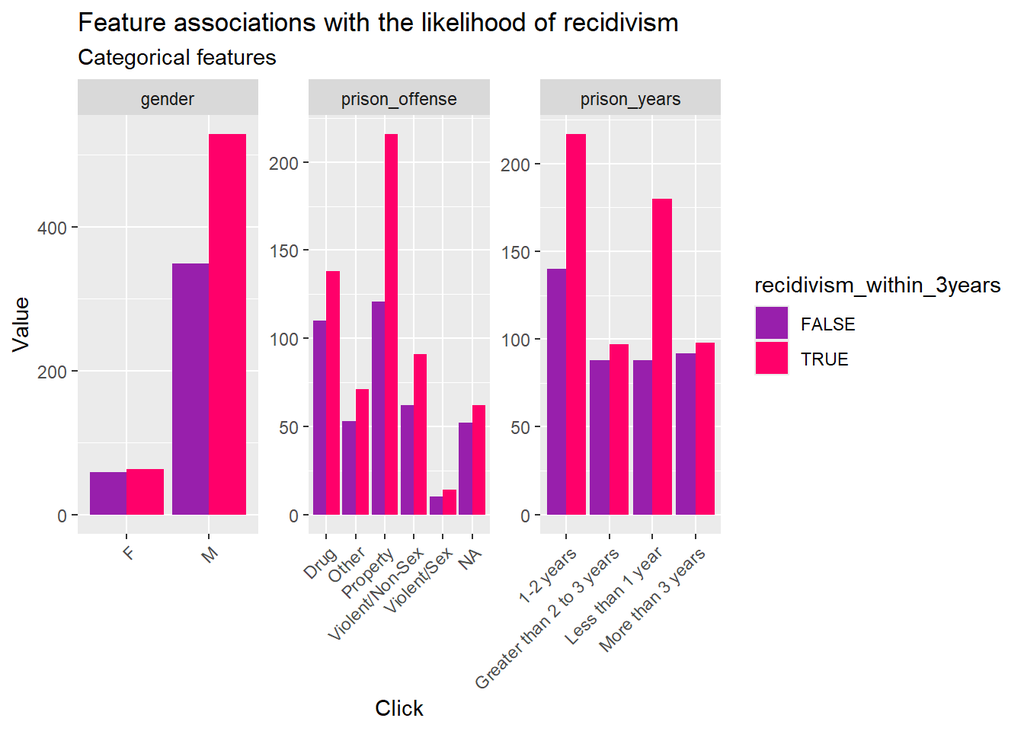

```r
rDivism %>%
    dplyr::select(gender, prison_offense, prison_years, recidivism_within_3years) %>%
    gather(Variable, value, -recidivism_within_3years) %>%
    count(Variable, value, recidivism_within_3years) %>%
      ggplot(., aes(value, n, fill = recidivism_within_3years)) +
        geom_bar(position = "dodge", stat="identity") +
        facet_wrap(~Variable, scales="free") +
        scale_fill_manual(values = palette2) +
        labs(x="Click", y="Value",
             title = "Feature associations with the likelihood of recidivism",
             subtitle = "Categorical features") +
        theme(axis.text.x = element_text(angle = 45, hjust = 1))
```

This code chunk initially groups the dataset `rDivism` by `prison_offense`, calculating the total count of `recidivism_within_3years` within each group, as well as the total count of observations and the national recidivism rate. We categorize individuals into age groups based on `age_at_release`, assigning them labels such as “Young”, “Middle Aged”, “Old”, and “Very Old”, and convert specific variables (`prior_arrest_episodes_misd` and `prior_arrest_episodes_felony`) into factors, replacing categories like “6 or more” and “10 or more” with numerical factors “6” and “10”, respectively. We do this so that we can better categorize and track what times recidivism is at its highest.

```r
rDivism <-
  rDivism %>%
  group_by(prison_offense) %>%
  summarize(totRD = sum(recidivism_within_3years), #except this is not a numeric thing its a binary thing
            n = n(),
            nationalrDivism = 100*(totRD/n)) %>%
  dplyr::select(-n, -totRD) %>%
  right_join(rDivism, .) %>%
    mutate(ageTimeFrame = case_when(age_at_release <= 32 ~ "Young",
                                  age_at_release > 33 & age_at_release <= 42 ~ "Middle Aged",
                                  age_at_release > 43 & age_at_release <= 48 ~ "Old",
                                  age_at_release > 48 ~ "Very Old"))

rDivism <- rDivism %>%
  mutate(prior_arrest_episodes_misd = as.factor(ifelse(prior_arrest_episodes_misd == "6 or more", "6", prior_arrest_episodes_misd)),
         prior_arrest_episodes_felony = as.factor(ifelse(prior_arrest_episodes_felony == "10 or more", "10", prior_arrest_episodes_felony)))
```

# Creating a logistic regression model

Our logistic regression model predicts a binary outcome. For Brian Kemp, that means there are two (2) options - a *1* or a *0*. A 1 indicates that there was recidivism, and a 0 indicates that were was not. There are also associates probabilities that can affet the outcome depending on the specific variables in the model. To create and test this model, we took our large NIJ dataset and split it into two equal parts - a training and a testing dataset.

When running the model, the depending variable is called ‘rDivismNumeric’ which is the binary outcome of recidivism instead of a TRUE/FALSE outcome.

```r
set.seed(3456)

rDivism$rDivismNumeric <-
  ifelse(rDivism$recidivism_within_3years == "TRUE", 1,0)

trainIndex <- createDataPartition(rDivism$recidivism_within_3years, p = 0.50, #splitting into 50-50 in training and testing models
                                  list = FALSE,
                                  times = 1)
rDivismTrain <- rDivism[ trainIndex,]
rDivismTest  <- rDivism[-trainIndex,]
```

```r
#not working and idk why - confused about the glm part
rDivismModel <- glm(rDivismNumeric ~ ., #glm is generalized linear model, taking in the defaults
                    data=rDivismTrain %>%
                    dplyr::select(-prison_offense, -prison_years, -gender, -recidivism_within_3years), # -recidivism_arrest_year1, -recidivism_arrest_year2, -recidivism_arrest_year3),
                  family="binomial"(link="logit"))
# i added gender into the model instead of agetime - if we want a more temporal variable
# we can add it too
summary(rDivismModel)
```

[output not shown]

```r
rDivismModel2 <- glm(rDivismNumeric ~ .,
                  data=rDivismTrain %>% dplyr::select(-prison_offense, -prison_years, -gender, -race, -education_level, -recidivism_arrest_year1, -recidivism_arrest_year2, -recidivism_arrest_year3, -recidivism_within_3years),
                  family="binomial" (link="logit"))

summary(rDivismModel2)
```

[output not shown]

```r
pR2(rDivismModel2) #McFadden is pseudo R squared
```

[output not shown]

```r
rDivismModel$xlevels[["prior_arrest_episodes_felony"]] <- union(rDivismModel$xlevels[["prior_arrest_episodes_felony"]], levels(rDivismTest$prior_arrest_episodes_felony))

rDivismTest$prior_arrest_episodes_felony[is.na(rDivismTest$prior_arrest_episodes_felony)] <- 9
levels_train <- levels(rDivismTrain$prior_arrest_episodes_felony)

# Relevel the factor variable in the new data
rDivismTest$prior_arrest_episodes_felony <- factor(rDivismTest$prior_arrest_episodes_felony, levels = levels_train)

testProbs <- data.frame(class = rDivismTest$recidivism_within_3years,
                        Outcome = as.factor(rDivismTest$rDivismNumeric),
                        Probs = predict(rDivismModel, rDivismTest, type= "response"))
```

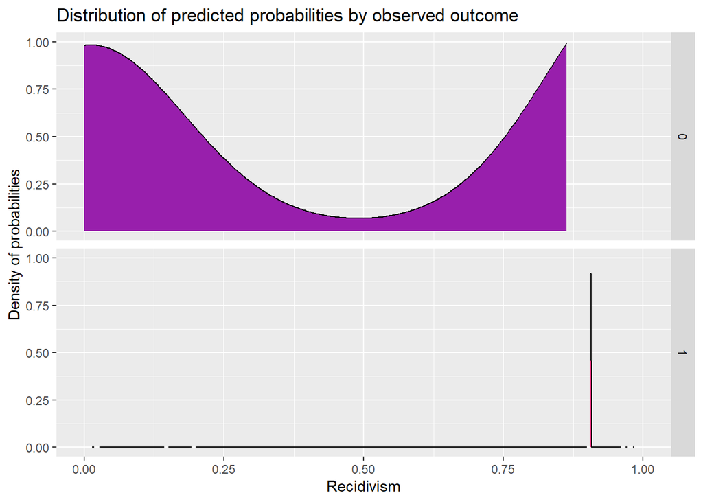

```r
ggplot(testProbs, aes(x = Probs, fill = as.factor(Outcome))) +
  geom_density() +
  facet_grid(Outcome ~ . ) +
  scale_fill_manual(values = palette2) +
  ylim(0,1)+
  labs(x = "Recidivism", y = "Density of probabilities",
       title = "Distribution of predicted probabilities by observed outcome") +
  theme(strip.text.x = element_text(size = 18),
        legend.position = "none")
```

This code generates a density plot using ggplot2 to visualize the distribution of predicted probabilities by observed outcomes. It assigns colors to different outcomes and arranges the plots in a grid based on the outcome. The x-axis represents the predicted probabilities of recidivism, while the y-axis shows the density of these probabilities.

## Confusion Matrix

```r
testProbs <-
  testProbs %>%
  mutate(predOutcome  = as.factor(ifelse(testProbs$Probs > 0.5 , 1, 0))) #setting threshold of 50%
```

```r
caret::confusionMatrix(testProbs$predOutcome, testProbs$Outcome,
                       positive = "1") #sensitivity tells us how good at predicting the 1, i.e. true positives. specificity is how good are we at predicting the 0, i.e. true negatives.
```

```
## Confusion Matrix and Statistics
##
##           Reference
## Prediction   0   1
##          0  52  35
##          1  71 147
##
##                Accuracy : 0.6525
##                  95% CI : (0.5961, 0.7058)
##     No Information Rate : 0.5967
##     P-Value [Acc > NIR] : 0.0263187
##
##                   Kappa : 0.2419
##
##  Mcnemar's Test P-Value : 0.0006751
##
##             Sensitivity : 0.8077
##             Specificity : 0.4228
##          Pos Pred Value : 0.6743
##          Neg Pred Value : 0.5977
##              Prevalence : 0.5967
##          Detection Rate : 0.4820
##    Detection Prevalence : 0.7148
##       Balanced Accuracy : 0.6152
##
##        'Positive' Class : 1
##
```

The Confusion Matrix presents the actual and predicted classes, allowing for a breakdown of correct and incorrect predictions. The statistics, such as accuracy, sensitivity, specificity, and positive predictive value, offer insights into different aspects of the model’s performance. Accuracy indicates overall correctness, while sensitivity and specificity highlight its ability to correctly identify positive and negative instances, respectively. Understanding these metrics is crucial for assessing the model’s strengths and weaknesses, guiding improvements, and determining its suitability for determining recidivism. In this specific case, an accuracy of 65.25% suggests moderate overall performance. Sensitivity at 80.77% indicates the model’s effectiveness in identifying true positives, while specificity at 42.28% shows room for improvement in correctly identifying true negatives. The positive predictive value of 67.43% signifies reasonable reliability in positive predictions, albeit with potential for enhancement.

## ROC Curve

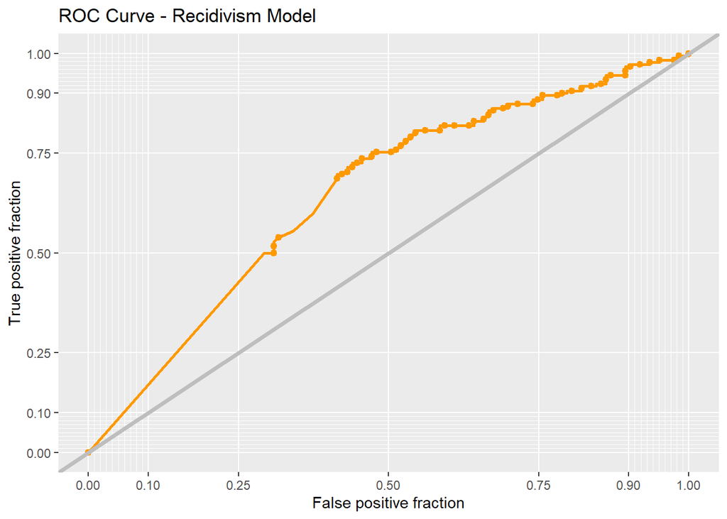

```r
ggplot(testProbs, aes(d = as.numeric(Outcome), m = Probs)) +
  geom_roc(n.cuts = 50, labels = FALSE, colour = "#FE9900") +
  style_roc(theme = theme_grey) +
  geom_abline(slope = 1, intercept = 0, size = 1.5, color = 'grey') +
  labs(title = "ROC Curve - Recidivism Model")
```

The ROC curve generated by the provided code is essential for evaluating the performance of a recidivism model. ROC (Receiver Operating Characteristic) curves illustrate the trade-off between the true positive rate (sensitivity) and the false positive rate (1 - specificity) across different decision thresholds. This visualization is crucial as it provides a comprehensive view of the model’s discrimination ability and helps in selecting the optimal threshold for classification. A higher area under the ROC curve (AUC) indicates better overall performance, with values closer to 1 signifying superior discrimination between positive and negative instances. By plotting the ROC curve, analysts can assess the model’s effectiveness in distinguishing between recidivism and non-recidivism cases, aiding in decision-making processes and further refining the model’s predictive capabilities. The inclusion of the title “ROC Curve - Recidivism Model” ensures clarity and context, facilitating easier interpretation and communication of results.

## Model Accuracy

```r
# Define train control
ctrl <- trainControl(method = "cv", number = 100, classProbs = TRUE, summaryFunction = twoClassSummary)

rDivism <- drop_na(rDivism)
rDivismTest <- drop_na(rDivismTest)
rDivism$prior_arrest_episodes_felony <- as.numeric(rDivism$prior_arrest_episodes_felony)
rDivismTest$prior_arrest_episodes_felony <- as.numeric(rDivismTest$prior_arrest_episodes_felony)

rDivism$recidivism_within_3years <- factor(rDivism$recidivism_within_3years)
levels(rDivism$recidivism_within_3years) <- make.names(levels(rDivism$recidivism_within_3years))

rDivismTest$recidivism_within_3years <- factor(rDivismTest$recidivism_within_3years)
levels(rDivismTest$recidivism_within_3years) <- make.names(levels(rDivismTest$recidivism_within_3years))

# Train the model
cvFit <- train(recidivism_within_3years ~ .,
               data = rDivismTest %>%
               dplyr::select(-prison_offense, -gender, -prior_arrest_episodes_felony,
                            -rDivismNumeric),
               method = "glm",
               family = "binomial",
               metric = "ROC",
               trControl = ctrl)

# View the results
cvFit
```

```
## Generalized Linear Model
##
## 269 samples
##  52 predictor
##   2 classes: 'FALSE.', 'TRUE.'
##
## No pre-processing
## Resampling: Cross-Validated (100 fold)
## Summary of sample sizes: 267, 267, 267, 266, 267, 267, ...
## Resampling results:
##
##   ROC  Sens  Spec
##   1    1     1
```

The results of the GLM applied to the recidivism dataset indicate promising performance in predicting whether individuals will reoffend after being incarcerated. With 269 samples and 52 predictors, the model was trained and evaluated using cross-validation with 100 folds. The binary classification task, distinguishing between ‘FALSE.’ and ‘TRUE.’ classes representing non-recidivism and recidivism respectively, yielded impressive (too impressive) results. The model achieved a perfect ROC value of 1, indicating excellent discrimination ability between the two classes. Moreover, both sensitivity and specificity were observed to be 1, signifying that the model identified both recidivating and non-recidivating individuals 100% of the time. These findings tell us that this GLM model is overfitted and can predict this 100% of the time with the dataframe given, which means that this model isn’t generalizeable to other datasets.

[figure not shown]

```r
dplyr::select(cvFit$resample, -Resample) %>%
  gather(metric, value) %>%
  left_join(gather(cvFit$results[2:4], metric, mean)) %>%
  ggplot(aes(value)) +
    geom_histogram(bins=35, fill = "#FF006A") +
    facet_wrap(~metric) +
    geom_vline(aes(xintercept = mean), colour = "#981FAC", linetype = 3, size = 1.5) +
    scale_x_continuous(limits = c(0, 1)) +
    labs(x="Goodness of Fit", y="Count", title="CV Goodness of Fit Metrics",
         subtitle = "Across-fold mean reprented as dotted lines")
```

This code constructs a visualization to assess the goodness-of-fit metrics derived from cross-validated model evaluation. Initially, the code selects relevant columns from the cross-validation results dataframe, excluding the ‘Resample’ column. Subsequently, it reshapes the data into a long format, facilitating visualization by grouping metrics into key-value pairs. This visualization provides a comprehensive overview of the distribution and mean values of goodness-of-fit metrics across cross-validation folds, aiding in the assessment of model performance and identifying potential areas for improvement.